# MCF7-test-RNAseq.map.count

## Download from SRA

using `prefetch` and `fastq-dump` is faster than only use 'fastq-dump'

```bash
prefetch SRR19193857 -O /mnt/storage/$USER/jupyternotebooks/assignment1/RNA-seq
```

```
2022-12-02T08:28:13 prefetch.3.0.0: Current preference is set to retrieve SRA Normalized Format files with full base quality scores.
2022-12-02T08:28:13 prefetch.3.0.0: 1) Downloading 'SRR19193857'...
2022-12-02T08:28:13 prefetch.3.0.0: SRA Normalized Format file is being retrieved, if this is different from your preference, it may be due to current file availability.
2022-12-02T08:28:13 prefetch.3.0.0:  Downloading via HTTPS...
2022-12-02T08:29:08 prefetch.3.0.0:  HTTPS download succeed
2022-12-02T08:29:11 prefetch.3.0.0:  'SRR19193857' is valid
2022-12-02T08:29:11 prefetch.3.0.0: 1) 'SRR19193857' was downloaded successfully
2022-12-02T08:29:11 prefetch.3.0.0: 'SRR19193857' has 0 unresolved dependencies
```

```bash
prefetch SRR19193856 -O /mnt/storage/$USER/jupyternotebooks/assignment1/RNA-seq
```

```
2022-12-02T08:44:28 prefetch.3.0.0: Current preference is set to retrieve SRA Normalized Format files with full base quality scores.
2022-12-02T08:44:28 prefetch.3.0.0: 1) Downloading 'SRR19193856'...
2022-12-02T08:44:28 prefetch.3.0.0: SRA Normalized Format file is being retrieved, if this is different from your preference, it may be due to current file availability.
2022-12-02T08:44:28 prefetch.3.0.0:  Downloading via HTTPS...
2022-12-02T08:45:22 prefetch.3.0.0:  HTTPS download succeed
2022-12-02T08:45:25 prefetch.3.0.0:  'SRR19193856' is valid
2022-12-02T08:45:25 prefetch.3.0.0: 1) 'SRR19193856' was downloaded successfully
2022-12-02T08:45:25 prefetch.3.0.0: 'SRR19193856' has 0 unresolved dependencies
```

```bash
prefetch SRR19193855 -O /mnt/storage/$USER/jupyternotebooks/assignment1/RNA-seq
```

```
2022-12-02T08:45:26 prefetch.3.0.0: Current preference is set to retrieve SRA Normalized Format files with full base quality scores.
2022-12-02T08:45:27 prefetch.3.0.0: 1) Downloading 'SRR19193855'...
2022-12-02T08:45:27 prefetch.3.0.0: SRA Normalized Format file is being retrieved, if this is different from your preference, it may be due to current file availability.
2022-12-02T08:45:27 prefetch.3.0.0:  Downloading via HTTPS...
2022-12-02T08:46:28 prefetch.3.0.0:  HTTPS download succeed
2022-12-02T08:46:30 prefetch.3.0.0:  'SRR19193855' is valid
2022-12-02T08:46:30 prefetch.3.0.0: 1) 'SRR19193855' was downloaded successfully
2022-12-02T08:46:30 prefetch.3.0.0: 'SRR19193855' has 0 unresolved dependencies
```

```bash
prefetch SRR19193854 -O /mnt/storage/$USER/jupyternotebooks/assignment1/RNA-seq
```

```
2022-12-02T08:46:31 prefetch.3.0.0: Current preference is set to retrieve SRA Normalized Format files with full base quality scores.
2022-12-02T08:46:31 prefetch.3.0.0: 1) Downloading 'SRR19193854'...
2022-12-02T08:46:31 prefetch.3.0.0: SRA Normalized Format file is being retrieved, if this is different from your preference, it may be due to current file availability.
2022-12-02T08:46:31 prefetch.3.0.0:  Downloading via HTTPS...
2022-12-02T08:47:03 prefetch.3.0.0:  HTTPS download succeed
2022-12-02T08:47:05 prefetch.3.0.0:  'SRR19193854' is valid
2022-12-02T08:47:05 prefetch.3.0.0: 1) 'SRR19193854' was downloaded successfully
2022-12-02T08:47:05 prefetch.3.0.0: 'SRR19193854' has 0 unresolved dependencies
```

```bash
fastq-dump --split-files /mnt/storage/$USER/jupyternotebooks/assignment1/RNA-seq/SRR19193857/SRR19193857.sra
# --split-files  Dump each read into separate file.Files will receive suffix corresponding to read number
```

```
Read 52437277 spots for /mnt/storage/r0823712/jupyternotebooks/assignment1/RNA-seq/SRR19193857/SRR19193857.sra
Written 52437277 spots for /mnt/storage/r0823712/jupyternotebooks/assignment1/RNA-seq/SRR19193857/SRR19193857.sra
```

```bash
fastq-dump --split-files /mnt/storage/$USER/jupyternotebooks/assignment1/RNA-seq/SRR19193856/SRR19193856.sra
```

```
Read 55985005 spots for /mnt/storage/r0823712/jupyternotebooks/assignment1/RNA-seq/SRR19193856/SRR19193856.sra
Written 55985005 spots for /mnt/storage/r0823712/jupyternotebooks/assignment1/RNA-seq/SRR19193856/SRR19193856.sra
```

```bash
fastq-dump --split-files /mnt/storage/$USER/jupyternotebooks/assignment1/RNA-seq/SRR19193855/SRR19193855.sra
```

```
Read 41535002 spots for /mnt/storage/r0823712/jupyternotebooks/assignment1/RNA-seq/SRR19193855/SRR19193855.sra
Written 41535002 spots for /mnt/storage/r0823712/jupyternotebooks/assignment1/RNA-seq/SRR19193855/SRR19193855.sra
```

```bash
fastq-dump --split-files /mnt/storage/$USER/jupyternotebooks/assignment1/RNA-seq/SRR19193854/SRR19193854.sra
```

```
Read 31654723 spots for /mnt/storage/r0823712/jupyternotebooks/assignment1/RNA-seq/SRR19193854/SRR19193854.sra
Written 31654723 spots for /mnt/storage/r0823712/jupyternotebooks/assignment1/RNA-seq/SRR19193854/SRR19193854.sra
```

```bash
wc -l SRR19193857.fastq
wc -l SRR19193856.fastq
wc -l SRR19193855.fastq
wc -l SRR19193854.fastq
# 4 lines = 1 read
```

```
209749108 SRR19193857.fastq
223940020 SRR19193856.fastq
166140008 SRR19193855.fastq
126618892 SRR19193854.fastq
```

```bash
head SRR19193857.fastq
```

```
@SRR19193857.1 NS500672:790:H37TMBGXG:1:11101:10423:1055 length=75
TGGTTNACAGCTACCTCCATTCTGGCAAGGGTGGGATGCACAGTCACCAGGAGGGACACATTTGTAGGCATACCA
+SRR19193857.1 NS500672:790:H37TMBGXG:1:11101:10423:1055 length=75
AAAAA#EEEEEEEEEEEEEEEEEEEEEEEEEEEEEEEEEEEEEEEEEEEEEEEEEEEEEEEEEEEEEEEEEEEE/
@SRR19193857.2 NS500672:790:H37TMBGXG:1:11101:24206:1055 length=75
CTGCTNAAAAGTTCTTTGAGACAATTCCATCAGCCTTAGCCAATCGGAGAATAGAATCATCTGACTCGCCCATCC
+SRR19193857.2 NS500672:790:H37TMBGXG:1:11101:24206:1055 length=75
AAAAA#EEEEEEEEEEEEEEEEAAEEEEEEEEEEAEEEEEEEEEEEEEEEEEEEEAEEEEEEEEEEEEEEEEEEE
@SRR19193857.3 NS500672:790:H37TMBGXG:1:11101:17342:1055 length=75
CTCCTNTCTCTCTCTCATTCCTCTCTCTCCCTCCCAGTCTCTGTCTCTCTCACTCACTCAGCTGCCTCTTTAGAC
```

## Quality control using FASTQC

```bash
/usr/bin/fastqc -o . SRR19193857.fastq
```

[output not shown]

```bash
/usr/bin/fastqc -o . SRR19193856.fastq
```

[output not shown]

```bash
/usr/bin/fastqc -o . SRR19193855.fastq
```

[output not shown]

```bash
/usr/bin/fastqc -o . SRR19193854.fastq
```

[output not shown]

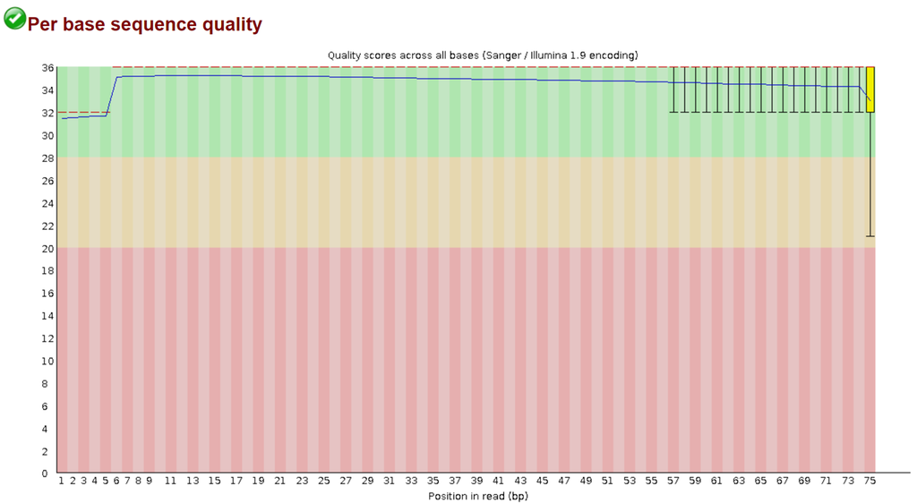

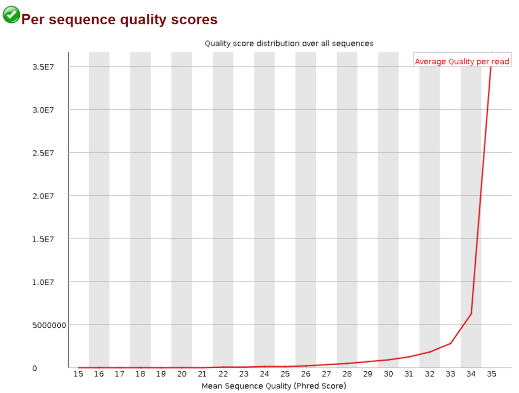

no sequence with low quality => all of sequence have high avarage quality score

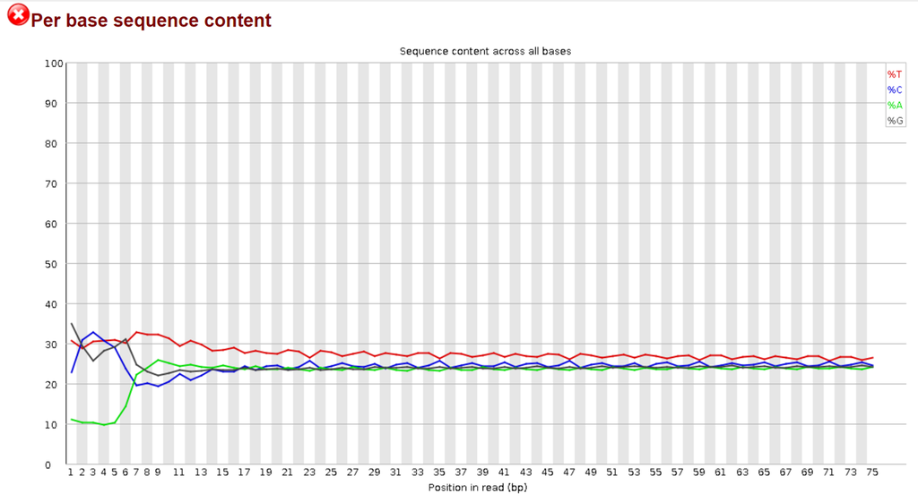

Theoretically, distribution of the four bases doesn't change with base position. However, the line is wobbing, it has a biased position. \ The reason is random hexamers (certain hexamers) are favoured during the priming step of library production.\ This index failed doesn't affect the result.

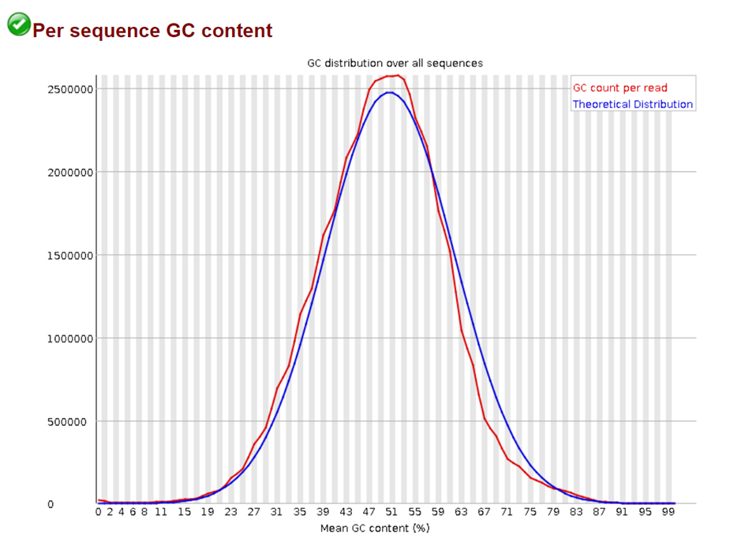

GC content across all the sequences, should be normal distribution and close to the theoretical distribution.\ The result is good.\ *If not match with blue line -> having specific contaminants in the library

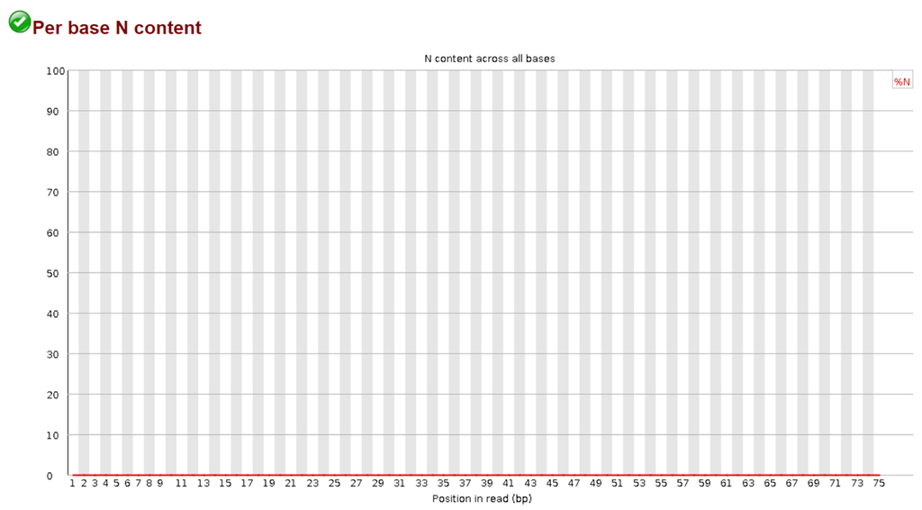

show uncalled bases in the library

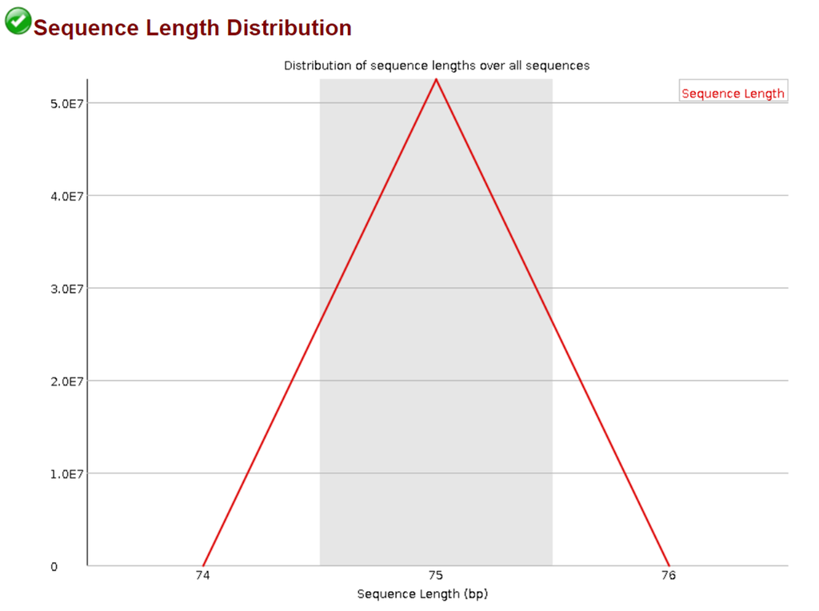

Show the library is all the same length or not.

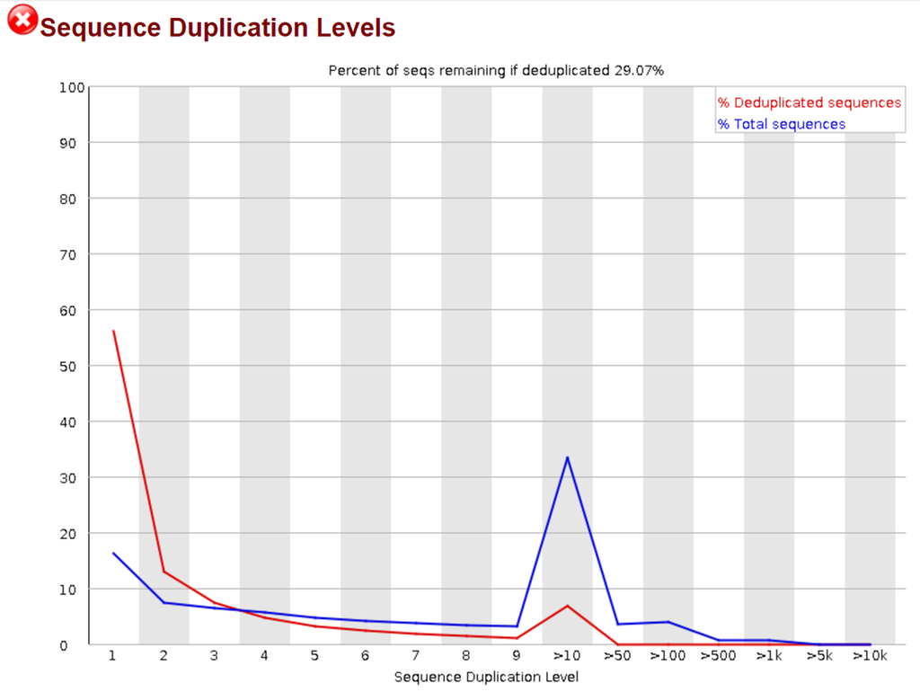

Show how unique the sequences are within the library. Sequence duplicate level 1 means sequence occurs once. \ The index failed (or say RNAseq almost always "fail") caused by highly expressed genes which are flagged as duplicates.\ Therefore, we don't need to worry about this fail.

*Sequences with low duplication levels (2-9 copies) => ‘normal’ genes \*Sequences with moderate duplication (10 – 100 copies) => rRNA or some repeat sequences.

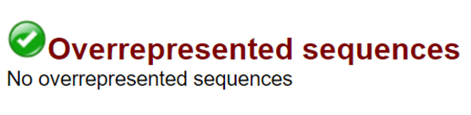

Look for individual sequence which are over represented (>0.1% of the total sequence) within the set.\ Possible Source: contaminants (primer or adaptor used in the various sequencing platforms)\ In the QC result, we don't have the overrepresented sequences (good).

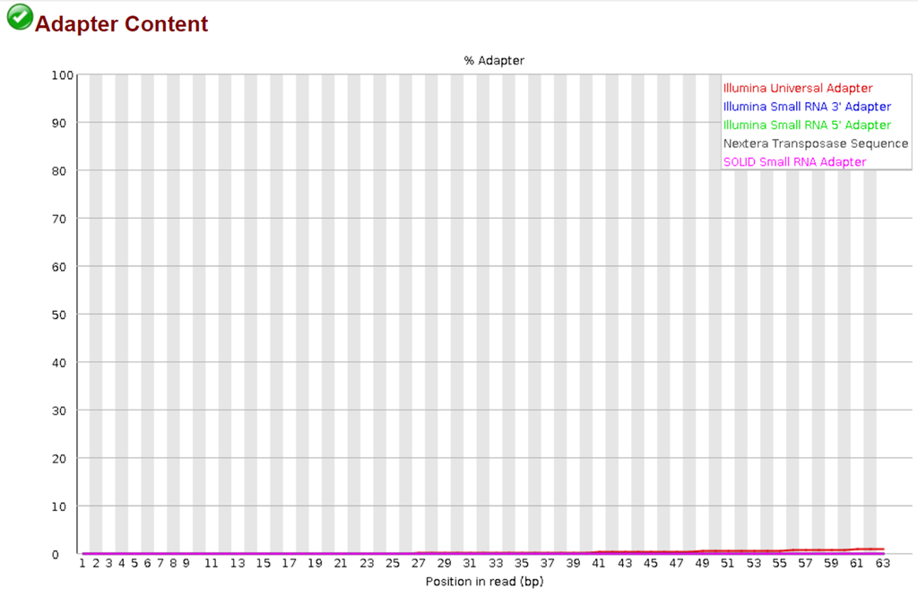

This index is good.

## Mapping to the genome

```bash
STAR --genomeDir /mnt/storage/data/resources/genomes/mm10/star/star_mm10_refGene_agat \
     --genomeLoad NoSharedMemory \
     --runThreadN 2 \
     --readFilesIn SRR19193857.fastq \
     --outFileNamePrefix C1.
#NoSharedMemory: do not use shared memory, each job will have its own private copy of the genome
```

```
Dec 02 21:48:59 ..... started STAR run
Dec 02 21:49:00 ..... loading genome
Dec 02 21:49:16 ..... started mapping
Dec 02 22:00:59 ..... finished successfully
```

```bash
STAR --genomeDir /mnt/storage/data/resources/genomes/mm10/star/star_mm10_refGene_agat \
     --genomeLoad NoSharedMemory \
     --runThreadN 2 \
     --readFilesIn SRR19193856.fastq \
     --outFileNamePrefix C2.
```

```
Dec 02 22:03:46 ..... started STAR run
Dec 02 22:03:46 ..... loading genome
Dec 02 22:04:16 ..... started mapping
Dec 02 22:17:52 ..... finished successfully
```

```bash
STAR --genomeDir /mnt/storage/data/resources/genomes/mm10/star/star_mm10_refGene_agat \
     --genomeLoad NoSharedMemory \
     --runThreadN 2 \
     --readFilesIn SRR19193855.fastq \
     --outFileNamePrefix K1.
```

```
Dec 02 22:19:43 ..... started STAR run
Dec 02 22:19:43 ..... loading genome
Dec 02 22:19:58 ..... started mapping
Dec 02 22:31:18 ..... finished successfully
```

```bash
STAR --genomeDir /mnt/storage/data/resources/genomes/mm10/star/star_mm10_refGene_agat \
     --genomeLoad NoSharedMemory \
     --runThreadN 2 \
     --readFilesIn SRR19193854.fastq \
     --outFileNamePrefix K2.
```

```
Dec 02 22:31:44 ..... started STAR run
Dec 02 22:31:44 ..... loading genome
Dec 02 22:31:59 ..... started mapping
Dec 02 22:41:21 ..... finished successfully
```

```bash
ls -l C1.*
```

```
-rw-r--r-- 1 r0823712 domain users 14007113292 Dec  2 22:00 C1.Aligned.out.sam
-rw-r--r-- 1 r0823712 domain users        1865 Dec  2 22:00 C1.Log.final.out
-rw-r--r-- 1 r0823712 domain users       18297 Dec  2 22:00 C1.Log.out
-rw-r--r-- 1 r0823712 domain users        1544 Dec  2 22:00 C1.Log.progress.out
-rw-r--r-- 1 r0823712 domain users     6025173 Dec  2 22:00 C1.SJ.out.tab
```

### SAM file structure

```bash
head -40 C1.Aligned.out.sam | grep '^@'
```

```
@HD	VN:1.4
@SQ	SN:chr1	LN:195471971
@SQ	SN:chr10	LN:130694993
@SQ	SN:chr11	LN:122082543
@SQ	SN:chr12	LN:120129022
@SQ	SN:chr13	LN:120421639
@SQ	SN:chr14	LN:124902244
@SQ	SN:chr15	LN:104043685
@SQ	SN:chr16	LN:98207768
@SQ	SN:chr17	LN:94987271
@SQ	SN:chr18	LN:90702639
@SQ	SN:chr19	LN:61431566
@SQ	SN:chr1_GL456210_random	LN:169725
@SQ	SN:chr1_GL456211_random	LN:241735
@SQ	SN:chr1_GL456212_random	LN:153618
@SQ	SN:chr1_GL456213_random	LN:39340
@SQ	SN:chr1_GL456221_random	LN:206961
@SQ	SN:chr2	LN:182113224
@SQ	SN:chr3	LN:160039680
@SQ	SN:chr4	LN:156508116
@SQ	SN:chr4_GL456216_random	LN:66673
@SQ	SN:chr4_JH584292_random	LN:14945
@SQ	SN:chr4_GL456350_random	LN:227966
@SQ	SN:chr4_JH584293_random	LN:207968
@SQ	SN:chr4_JH584294_random	LN:191905
@SQ	SN:chr4_JH584295_random	LN:1976
@SQ	SN:chr5	LN:151834684
@SQ	SN:chr5_JH584296_random	LN:199368
@SQ	SN:chr5_JH584297_random	LN:205776
@SQ	SN:chr5_JH584298_random	LN:184189
@SQ	SN:chr5_GL456354_random	LN:195993
@SQ	SN:chr5_JH584299_random	LN:953012
@SQ	SN:chr6	LN:149736546
@SQ	SN:chr7	LN:145441459
@SQ	SN:chr7_GL456219_random	LN:175968
@SQ	SN:chr8	LN:129401213
@SQ	SN:chr9	LN:124595110
@SQ	SN:chrM	LN:16299
@SQ	SN:chrX	LN:171031299
@SQ	SN:chrX_GL456233_random	LN:336933
```

```bash
head -100 C1.Aligned.out.sam | grep -v '^@'
#-v, --invert-match        select non-matching lines
```

```
SRR19193857.1	16	chr3	39009154	255	75M	*	0	0	TGGTATGCCTACAAATGTGTCCCTCCTGGTGACTGTGCATCCCACCCTTGCCAGAATGGAGGTAGCTGTNAACCA	/EEEEEEEEEEEEEEEEEEEEEEEEEEEEEEEEEEEEEEEEEEEEEEEEEEEEEEEEEEEEEEEEEEEE#AAAAA	NH:i:1	HI:i:1	AS:i:72	nM:i:0
SRR19193857.2	16	chr2	180258053	255	5M172N56M92N14M	*	0	0	GGATGGGCGAGTCAGATGATTCTATTCTCCGATTGGCTAAGGCTGATGGAATTGTCTCAAAGAACTTTTNAGCAG	EEEEEEEEEEEEEEEEEEEAEEEEEEEEEEEEEEEEEEEEAEEEEEEEEEEAAEEEEEEEEEEEEEEEE#AAAAA	NH:i:1	HI:i:1	AS:i:76	nM:i:0
SRR19193857.3	16	chr19	59464300	255	72M3S	*	0	0	GTCTAAAGAGGCAGCTGAGTGAGTGAGAGAGACAGAGACTGGGAGGGAGAGAGAGGAATGAGAGAGAGANAGGAG	EEEAEEEEEEEEEEEEEEEEEEEEEEEEEEEEEEEEEEEEEEEEEEEEEEEEEEEEEEEEEEEEEEEEE#AAAAA	NH:i:1	HI:i:1	AS:i:69	nM:i:0
SRR19193857.4	16	chr11	88051458	255	75M	*	0	0	TTTCTTTGAAAAAAATAAACATTTTTTAAAAAACGATGCATGGTTGTCCTTTTTCCTCTTGTAAAATTTNGATTG	EEEEEEEEEEEEEEEEEEEEEEEEEEEEEEEEEEEEEEEEEEEEEEEEEEEEEEEEEEEEEEEEEEEEE#AAAAA	NH:i:1	HI:i:1	AS:i:72	nM:i:0
SRR19193857.5	16	chr6	67267329	255	75M	*	0	0	GCAAGAACCCGCTGCCCCCCAGCGTCGGCGTGGCCGACAAAACGGAGGAGACGCAGCCGCCGGTGGCGCNTAAGA	/EEEAEAEEEEE6EEEEEEEEEEE/EEEEEEEEEEEEEEEEE/EEEEEEEEEEEEEEEEEEEEAEEEEE#AAAAA	NH:i:1	HI:i:1	AS:i:70	nM:i:1
SRR19193857.6	16	chr12	40276098	255	75M	*	0	0	TAAGTACAGGCATGAAGTGGAAACTTCTAGTCTCTTTGGAAAGTTAGTTATGTCAAATGATGTTAAAGTNGATGC	6EEEEEEEAEEEEEEEEEEEEEEEEEEEEEEEEEEEEEEEEEEEEEEEEEEEEEEEEEEEEEEEEEEEE#AAAAA	NH:i:1	HI:i:1	AS:i:72	nM:i:0
SRR19193857.7	16	chr15	76345192	255	74M1S	*	0	0	GAAGTCTTGGAGTATGATGATGGTGAGTGTCCTTTGCCATGGGTTCTCTCCTACTCCTAGCATGCTTCCNTGATG	EEEEEEEEEEEEEEEEEEEEEEEEEEEEEEEEEEEEEEEEEEEEEEEEEEEEEEEEEEEEEEEEEEEEE#AAAAA	NH:i:1	HI:i:1	AS:i:71	nM:i:0
SRR19193857.8	0	chr12	21395026	255	35M1221N40M	*	0	0	AGTGTNTCAAGCTCTGCGATGGCCTCATCAAAAGCCGTTTTAGCCAGTGTACAGGCAAGCTCTGGATTATTAAGG	AAAAA#EEEEEEEEEEAEEEEEEEEEEEE/E/EAE/EEAEEEE/EEEEEEEEEEEEEEE6EEEEE/EEAEE/<EE	NH:i:1	HI:i:1	AS:i:71	nM:i:1
SRR19193857.9	0	chr1	24614136	3	2S73M	*	0	0	CCGTGNATTAATAAGTGTCCTGCAGTAATGTTAGCTGTAAGCCGGACTGCTAATGCCATTGGTTGAATAAATAGG	AAAAA#EEEEEEEEEEEEEEEEEEEEEEEEEEEEEEEEEEEEEEEEEEEEEEEEEEEEEEEEEEEEEEEEEEEEE	NH:i:2	HI:i:1	AS:i:70	nM:i:0
SRR19193857.9	272	chrM	8370	3	73M2S	*	0	0	CCTATTTATTCAACCAATGGCATTAGCAGTCCGGCTTACAGCTAACATTACTGCAGGACACTTATTAATNCACGG	EEEEEEEEEEEEEEEEEEEEEEEEEEEEEEEEEEEEEEEEEEEEEEEEEEEEEEEEEEEEEEEEEEEEE#AAAAA	NH:i:2	HI:i:2	AS:i:70	nM:i:0
SRR19193857.11	0	chr11	33160410	255	31M387N44M	*	0	0	TCATCNTCAGACTCTGCATCTTCCTCTACAGCTACTAGATGCTGTCCACTAATGTGCACAGGCCCTGAACCACAC	AAAAA#EEAEAEEEEEEEEEEEAEEEEEEEEEEEEEEEEEEEEEEEEEEEEEEAEEEEEEEEEEEEEEEEA/EAE	NH:i:1	HI:i:1	AS:i:74	nM:i:0
SRR19193857.12	16	chr2	127237863	255	75M	*	0	0	TCAATGATCCACATGTGAAGACCAATCTGCTGCCGCAGGCTCACCTGTCCCGCATGCAGCTAAGTGCTGNACTAC	EEEEEEEEEEEEEEEEEEEEEEEEEEEEEEEEEEEEEEEEEEEEEEEEEEEEEEEEEEEEEEEEEEEEE#AAAAA	NH:i:1	HI:i:1	AS:i:70	nM:i:1
SRR19193857.13	16	chr3	103052928	255	4M1723N69M2S	*	0	0	GAGGGGGATATGAAAGGTGAAGTGTATCCTTTTGGCATAGTTGGGATGGCCAACAAAGGGGATTGCCTANAGACA	EEEEEEEEEEEEEEEEEAEEEEEEEEEEEEEEEEEEEEEEEEEEEEEEEEEEEEEEEEEEEEEEEEEEE#AAAAA	NH:i:1	HI:i:1	AS:i:71	nM:i:0
SRR19193857.14	0	chr11	84491603	255	75M	*	0	0	CCCTGNGTTGGCTATTTATGATATCAGGAGTGATGTACTTGCCTGTGGCCCTGGCAGCTGGCTGAGGCTGTACCC	AAAAA#EEEEEEEEEEEEEEEEEEEEEEEEEEEEEEEEEEEEEEEEEEEEEEEEEEEEEEEEEEEEEEEEEEEEA	NH:i:1	HI:i:1	AS:i:68	nM:i:2
SRR19193857.15	0	chr11	68211265	255	75M	*	0	0	TGTGGNGAGGTCAGAGTCTGAGTACCGGTGCTGGTGTGACCTTGGGCACGTGGACATGTCTTTTTACTGGTGAAC	AAAAA#EEEEEEEEEEEEEEEEEEEEEEEEEEEEEEEEEEEEEEEEEEEEEEEEEEEEE/EEEEEEEEEEEEEEE	NH:i:1	HI:i:1	AS:i:72	nM:i:0
SRR19193857.16	0	chr5	149155575	3	75M	*	0	0	TAGTTNCAAGGTGGCGTCCTCGTCACACACAAACACAGTGCGGGGGTGCTGCTGAAAGGCGGACACCGTCCACAT	AAAAA#EEEEEEEEEEEEEEEEEEEEEEEEEEEEEEEEEEEEEEEEEEEEEEEEEEEEEEEEEEEEEEEEEEEEE	NH:i:2	HI:i:1	AS:i:72	nM:i:0
SRR19193857.16	256	chr18	38330514	3	75M	*	0	0	TAGTTNCAAGGTGGCGTCCTCGTCACACACAAACACAGTGCGGGGGTGCTGCTGAAAGGCGGACACCGTCCACAT	AAAAA#EEEEEEEEEEEEEEEEEEEEEEEEEEEEEEEEEEEEEEEEEEEEEEEEEEEEEEEEEEEEEEEEEEEEE	NH:i:2	HI:i:2	AS:i:72	nM:i:0
SRR19193857.17	0	chr7	16917434	255	6S59M92N10M	*	0	0	ATCATNATCCTTCATCTTTCTGGCCATCATGGTCAAGAACTCTGGGAAGTCAATGGTCCCATTGCCATCAGCATC	AAAAA#EEEEEEEEEEEEEEEEEEEEEEEEEEEEEEEEEEEEEEEEEEEEEEEEEEEEEEEEEEEEEEEEEEEEE	NH:i:1	HI:i:1	AS:i:69	nM:i:0
SRR19193857.18	0	chr5	65291184	255	11M2463N64M	*	0	0	GGGCTNACAGACTCTCTCTTAGTTGGAGAAACTTTCGTTTTCTTAGGAGTTGTTTTCTCTCCTTTGGGTTCAGTG	AAAAA#EEEAEEEEEEEEEEEEEEEAEEEEEAEEEEEE6EEEEE/EEEEEEE<EEEEEEEEE<6EEEAEEEEE/E	NH:i:1	HI:i:1	AS:i:73	nM:i:0
SRR19193857.19	16	chrX	73503293	255	42M19500N33M	*	0	0	AGCCACAGCAGAGGCCGCGGTGGCGGCTGTGCCCATGCCGGGGTGTTCACACTTAGCCTCTTTTCCACCNCCACC	EEEEAEEEEEEEEEEEEEEEEEEEAEEEEEEEEEEEEEEEEEEEEEEEEEEEEEEEEEEEEEEEEEEEE#AAAAA	NH:i:1	HI:i:1	AS:i:72	nM:i:0
```

[output cut: 11 more lines]

### Sort and compressed the SAM file to BAM file (samtools)

```bash
samtools sort -o C1.bam C1.Aligned.out.sam
#-o FILE    Write final output to FILE rather than standard output
#writing to a file (fast) vs printing to the console (slow, refresh the screen each time something is written)
```

```
[bam_sort_core] merging from 16 files and 1 in-memory blocks...
```

```bash
samtools sort -o C2.bam C2.Aligned.out.sam
```

```
[bam_sort_core] merging from 17 files and 1 in-memory blocks...
```

```bash
samtools sort -o K1.bam K1.Aligned.out.sam
```

```
[bam_sort_core] merging from 12 files and 1 in-memory blocks...
```

```bash
samtools sort -o K2.bam K2.Aligned.out.sam
```

```
[bam_sort_core] merging from 9 files and 1 in-memory blocks...
```

```bash
ls -l C1*[bs]am
```

```
-rw-r--r-- 1 r0823712 domain users 14007113292 Dec  2 22:00 C1.Aligned.out.sam
-rw-r--r-- 1 r0823712 domain users  1365010376 Dec  2 22:50 C1.bam
```

### Generate an index (samtools)

```bash
samtools index C1.bam
```

```bash
samtools index C2.bam
```

```bash
samtools index K1.bam
```

```bash
samtools index K2.bam
```

```bash
ls -l C1*[bs]a[mi]
```

```
-rw-r--r-- 1 r0823712 domain users 14007113292 Dec  2 22:00 C1.Aligned.out.sam
-rw-r--r-- 1 r0823712 domain users  1365010376 Dec  2 22:50 C1.bam
-rw-r--r-- 1 r0823712 domain users     3481120 Dec  2 23:22 C1.bam.bai
```

### Inspect the BAM files

```bash
ls -l *.ba[mi]
```

```
-rw-r--r-- 1 r0823712 domain users 1365010376 Dec  2 22:50 C1.bam
-rw-r--r-- 1 r0823712 domain users    3481120 Dec  2 23:22 C1.bam.bai
-rw-r--r-- 1 r0823712 domain users 1466255262 Dec  2 23:00 C2.bam
-rw-r--r-- 1 r0823712 domain users    3524216 Dec  2 23:22 C2.bam.bai
-rw-r--r-- 1 r0823712 domain users  941863711 Dec  2 23:06 K1.bam
-rw-r--r-- 1 r0823712 domain users    3222928 Dec  2 23:22 K1.bam.bai
-rw-r--r-- 1 r0823712 domain users  715722212 Dec  2 23:16 K2.bam
-rw-r--r-- 1 r0823712 domain users    3131984 Dec  2 23:23 K2.bam.bai
```

```bash
samtools view C1.bam | head -3
```

```
SRR19193857.4710502	16	chr1	3004215	255	71M4S	*	0	0	ACAAGCAAACAAACAAACAAAAAACAAACAACAAAAAAACACACAAAAAAACAAACCTTTAAATTATAGGCGGCG	/EEEEEEEEEEEEEEEEEEEEEEEEEEEEEEEEEEEEEEEEEEEEEEEEEEEEEEEEEEEEEEEEEEEEEAAAAA	NH:i:1	HI:i:1	AS:i:69	nM:i:0
SRR19193857.9000581	16	chr1	3004215	255	71M4S	*	0	0	ACAAGCAAACAAACAAACAAAAAACAAACAACAAAAAAACACACAAAAAAACAAACCTTTAAATTATAGGCGGCG	AEEEEEEEAEEEEEEEEEEEEEEEEEEEEEEEEEEEEEEEEEEEEEEEEEEEEEEEEEEEEEEEEEEEEEAAAAA	NH:i:1	HI:i:1	AS:i:69	nM:i:0
SRR19193857.18740214	16	chr1	3004215	255	71M4S	*	0	0	ACAAGCAAACAAACAAACAAAAAACAAACAACAAAAAAACACACAAAAAAACAAACCTTTAAATTATAGGCGGCG	EEEEAEEEEEEEEEEEEEEEEEEEEEEEEEEEEEEEEEEEEEAEEEEEEEEEEEEEEEEAEEEEEEEEEEAAAAA	NH:i:1	HI:i:1	AS:i:69	nM:i:0
samtools view: writing to standard output failed: Broken pipe
samtools view: error closing standard output: -1
```

```bash
#see how many reads map to each chromosome
samtools idxstats C1.bam  #chrM: mitochondrial chromosome
```

```
chr1	195471971	3971857	0
chr10	130694993	2822805	0
chr11	122082543	4771140	0
chr12	120129022	1994016	0
chr13	120421639	2114435	0
chr14	124902244	2030790	0
chr15	104043685	2397521	0
chr16	98207768	1690640	0
chr17	94987271	2823149	0
chr18	90702639	1659466	0
chr19	61431566	1816305	0
chr1_GL456210_random	169725	813	0
chr1_GL456211_random	241735	1264	0
chr1_GL456212_random	153618	818	0
chr1_GL456213_random	39340	160	0
chr1_GL456221_random	206961	982	0
chr2	182113224	4301579	0
chr3	160039680	2482487	0
chr4	156508116	3762961	0
chr4_GL456216_random	66673	2389	0
chr4_JH584292_random	14945	1	0
chr4_GL456350_random	227966	2548	0
chr4_JH584293_random	207968	2857	0
chr4_JH584294_random	191905	3672	0
chr4_JH584295_random	1976	962	0
chr5	151834684	3931770	0
chr5_JH584296_random	199368	517	0
chr5_JH584297_random	205776	473	0
chr5_JH584298_random	184189	575	0
chr5_GL456354_random	195993	353	0
chr5_JH584299_random	953012	2386	0
chr6	149736546	2652367	0
chr7	145441459	4119619	0
chr7_GL456219_random	175968	211	0
chr8	129401213	2921701	0
chr9	124595110	3535462	0
chrM	16299	1603149	0
chrX	171031299	1928499	0
chrX_GL456233_random	336933	1935	0
chrY	91744698	239849	0
```

[output cut: 12 more lines]

```
chrUn_GL456392	23629	617	0
chrUn_GL456393	55711	273	0
chrUn_GL456394	24323	78	0
chrUn_GL456359	22974	10	0
chrUn_GL456360	31704	80	0
chrUn_GL456396	21240	661	0
chrUn_GL456372	28664	155	0
chrUn_GL456387	24685	2	0
chrUn_GL456389	28772	397	0
chrUn_GL456370	26764	979	0
chrUn_GL456379	72385	1976	0
chrUn_GL456366	47073	219	0
chrUn_GL456368	20208	114	0
chrUn_JH584304	114452	15153	0
*	0	0	0
```

```bash
ls *.bam
```

```
C1.bam  C2.bam  K1.bam  K2.bam
```

reads in Eya1 gene. Also check the Eya1 is knock out completely.

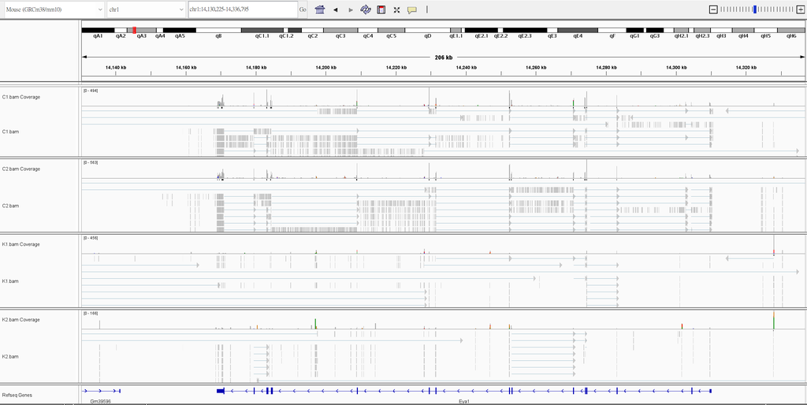

reads in the intron region of Six2 gene

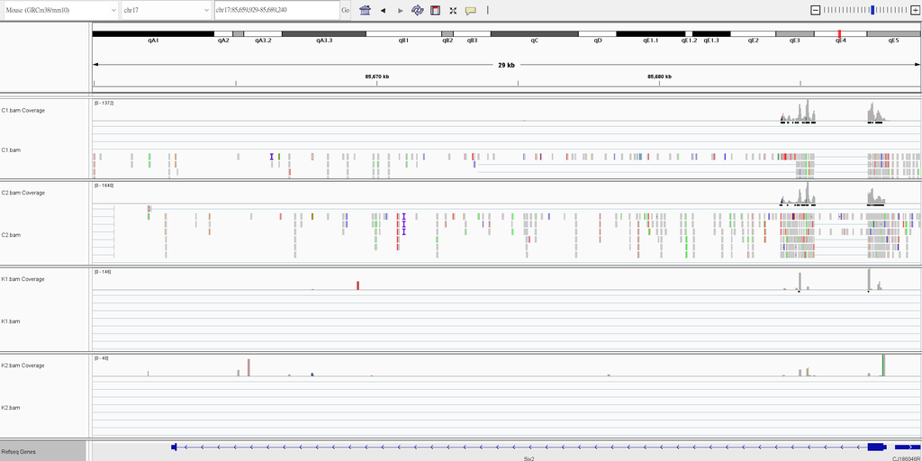

```bash
#distribution of mapping flags
samtools flagstat C1.bam
```

```
59633900 + 0 in total (QC-passed reads + QC-failed reads)
9368965 + 0 secondary
0 + 0 supplementary
0 + 0 duplicates
59633900 + 0 mapped (100.00% : N/A)
0 + 0 paired in sequencing
0 + 0 read1
0 + 0 read2
0 + 0 properly paired (N/A : N/A)
0 + 0 with itself and mate mapped
0 + 0 singletons (N/A : N/A)
0 + 0 with mate mapped to a different chr
0 + 0 with mate mapped to a different chr (mapQ>=5)
```

```bash
samtools flagstat C2.bam
```

```
62919771 + 0 in total (QC-passed reads + QC-failed reads)
9926269 + 0 secondary
0 + 0 supplementary
0 + 0 duplicates
62919771 + 0 mapped (100.00% : N/A)
0 + 0 paired in sequencing
0 + 0 read1
0 + 0 read2
0 + 0 properly paired (N/A : N/A)
0 + 0 with itself and mate mapped
0 + 0 singletons (N/A : N/A)
0 + 0 with mate mapped to a different chr
0 + 0 with mate mapped to a different chr (mapQ>=5)
```

```bash
samtools flagstat K1.bam
```

```
45263018 + 0 in total (QC-passed reads + QC-failed reads)
7682650 + 0 secondary
0 + 0 supplementary
0 + 0 duplicates
45263018 + 0 mapped (100.00% : N/A)
0 + 0 paired in sequencing
0 + 0 read1
0 + 0 read2
0 + 0 properly paired (N/A : N/A)
0 + 0 with itself and mate mapped
0 + 0 singletons (N/A : N/A)
0 + 0 with mate mapped to a different chr
0 + 0 with mate mapped to a different chr (mapQ>=5)
```

```bash
samtools flagstat K2.bam
```

```
34203636 + 0 in total (QC-passed reads + QC-failed reads)
5736780 + 0 secondary
0 + 0 supplementary
0 + 0 duplicates
34203636 + 0 mapped (100.00% : N/A)
0 + 0 paired in sequencing
0 + 0 read1
0 + 0 read2
0 + 0 properly paired (N/A : N/A)
0 + 0 with itself and mate mapped
0 + 0 singletons (N/A : N/A)
0 + 0 with mate mapped to a different chr
0 + 0 with mate mapped to a different chr (mapQ>=5)
```

## reads to gene counts

```bash
ln -sf /mnt/storage/data/resources/genomes/mm10/mm10.refGene.agat.gtf .
```

```bash
ls -l *gtf
```

```
lrwxrwxrwx 1 r0823712 domain users 62 Dec  2 20:10 mm10.refGene.agat.gtf -> /mnt/storage/data/resources/genomes/mm10/mm10.refGene.agat.gtf
```

```bash
grep -w Eya1 /mnt/storage/data/resources/genomes/mm10/mm10.refGene.agat.gtf
#-w, --word-regexp         force PATTERN to match only whole words
```

```
chr1	refGene	gene	14168958	14310199	.	-	.	gene_id "Eya1"; transcript_id "NM_001252192"; ID "Eya1"; gene_name "Eya1";
chr1	refGene	transcript	14168958	14310199	.	-	.	gene_id "Eya1"; transcript_id "NM_010164"; ID "NM_010164"; Parent "Eya1"; gene_name "Eya1";
chr1	refGene	exon	14168958	14170996	.	-	.	gene_id "Eya1"; transcript_id "NM_010164"; ID "NM_010164.1"; Parent "NM_010164"; exon_id "NM_010164.1"; exon_number "1"; gene_name "Eya1";
chr1	refGene	exon	14179480	14179580	.	-	.	gene_id "Eya1"; transcript_id "NM_010164"; ID "NM_010164.2"; Parent "NM_010164"; exon_id "NM_010164.2"; exon_number "2"; gene_name "Eya1";
chr1	refGene	exon	14183157	14183278	.	-	.	gene_id "Eya1"; transcript_id "NM_010164"; ID "NM_010164.3"; Parent "NM_010164"; exon_id "NM_010164.3"; exon_number "3"; gene_name "Eya1";
chr1	refGene	exon	14183381	14183495	.	-	.	gene_id "Eya1"; transcript_id "NM_010164"; ID "NM_010164.4"; Parent "NM_010164"; exon_id "NM_010164.4"; exon_number "4"; gene_name "Eya1";
chr1	refGene	exon	14184349	14184509	.	-	.	gene_id "Eya1"; transcript_id "NM_010164"; ID "NM_010164.5"; Parent "NM_010164"; exon_id "NM_010164.5"; exon_number "5"; gene_name "Eya1";
chr1	refGene	exon	14184626	14184684	.	-	.	gene_id "Eya1"; transcript_id "NM_010164"; ID "NM_010164.6"; Parent "NM_010164"; exon_id "NM_010164.6"; exon_number "6"; gene_name "Eya1";
chr1	refGene	exon	14208895	14208984	.	-	.	gene_id "Eya1"; transcript_id "NM_010164"; ID "NM_010164.7"; Parent "NM_010164"; exon_id "NM_010164.7"; exon_number "7"; gene_name "Eya1";
chr1	refGene	exon	14229493	14229576	.	-	.	gene_id "Eya1"; transcript_id "NM_010164"; ID "NM_010164.8"; Parent "NM_010164"; exon_id "NM_010164.8"; exon_number "8"; gene_name "Eya1";
chr1	refGene	exon	14231413	14231552	.	-	.	gene_id "Eya1"; transcript_id "NM_010164"; ID "NM_010164.9"; Parent "NM_010164"; exon_id "NM_010164.9"; exon_number "9"; gene_name "Eya1";
chr1	refGene	exon	14252428	14252614	.	-	.	gene_id "Eya1"; transcript_id "NM_010164"; ID "NM_010164.10"; Parent "NM_010164"; exon_id "NM_010164.10"; exon_number "10"; gene_name "Eya1";
chr1	refGene	exon	14253020	14253102	.	-	.	gene_id "Eya1"; transcript_id "NM_010164"; ID "NM_010164.11"; Parent "NM_010164"; exon_id "NM_010164.11"; exon_number "11"; gene_name "Eya1";
chr1	refGene	exon	14270705	14270827	.	-	.	gene_id "Eya1"; transcript_id "NM_010164"; ID "NM_010164.12"; Parent "NM_010164"; exon_id "NM_010164.12"; exon_number "12"; gene_name "Eya1";
chr1	refGene	exon	14274065	14274210	.	-	.	gene_id "Eya1"; transcript_id "NM_010164"; ID "NM_010164.13"; Parent "NM_010164"; exon_id "NM_010164.13"; exon_number "13"; gene_name "Eya1";
chr1	refGene	exon	14274534	14274603	.	-	.	gene_id "Eya1"; transcript_id "NM_010164"; ID "NM_010164.14"; Parent "NM_010164"; exon_id "NM_010164.14"; exon_number "14"; gene_name "Eya1";
chr1	refGene	exon	14283121	14283198	.	-	.	gene_id "Eya1"; transcript_id "NM_010164"; ID "NM_010164.15"; Parent "NM_010164"; exon_id "NM_010164.15"; exon_number "15"; gene_name "Eya1";
chr1	refGene	exon	14302770	14302897	.	-	.	gene_id "Eya1"; transcript_id "NM_010164"; ID "NM_010164.16"; Parent "NM_010164"; exon_id "NM_010164.16"; exon_number "16"; gene_name "Eya1";
chr1	refGene	exon	14304425	14304474	.	-	.	gene_id "Eya1"; transcript_id "NM_010164"; ID "NM_010164.17"; Parent "NM_010164"; exon_id "NM_010164.17"; exon_number "17"; gene_name "Eya1";
chr1	refGene	exon	14309646	14310199	.	-	.	gene_id "Eya1"; transcript_id "NM_010164"; ID "NM_010164.18"; Parent "NM_010164"; exon_id "NM_010164.18"; exon_number "18"; gene_name "Eya1";
chr1	refGene	CDS	14170919	14170996	.	-	0	gene_id "Eya1"; transcript_id "NM_010164"; ID "cds-118035"; Parent "NM_010164"; exon_id "NM_010164.1"; exon_number "1"; gene_name "Eya1";
chr1	refGene	CDS	14179480	14179580	.	-	2	gene_id "Eya1"; transcript_id "NM_010164"; ID "cds-118036"; Parent "NM_010164"; exon_id "NM_010164.2"; exon_number "2"; gene_name "Eya1";
chr1	refGene	CDS	14183157	14183278	.	-	1	gene_id "Eya1"; transcript_id "NM_010164"; ID "cds-118037"; Parent "NM_010164"; exon_id "NM_010164.3"; exon_number "3"; gene_name "Eya1";
chr1	refGene	CDS	14183381	14183495	.	-	2	gene_id "Eya1"; transcript_id "NM_010164"; ID "cds-118038"; Parent "NM_010164"; exon_id "NM_010164.4"; exon_number "4"; gene_name "Eya1";
chr1	refGene	CDS	14184349	14184509	.	-	1	gene_id "Eya1"; transcript_id "NM_010164"; ID "cds-118039"; Parent "NM_010164"; exon_id "NM_010164.5"; exon_number "5"; gene_name "Eya1";
chr1	refGene	CDS	14184626	14184684	.	-	0	gene_id "Eya1"; transcript_id "NM_010164"; ID "cds-118040"; Parent "NM_010164"; exon_id "NM_010164.6"; exon_number "6"; gene_name "Eya1";
```

[output cut: 96 more lines]

```bash
featureCounts \
    -Q 10 \
    -g gene_name \
    -a /mnt/storage/data/resources/genomes/mm10/mm10.refGene.agat.gtf \
    -o all.counts \
    C1.bam C2.bam K1.bam K2.bam
```

```
        ==========     _____ _    _ ____  _____  ______          _____
        =====         / ____| |  | |  _ \|  __ \|  ____|   /\   |  __ \
          =====      | (___ | |  | | |_) | |__) | |__     /  \  | |  | |
            ====      \___ \| |  | |  _ <|  _  /|  __|   / /\ \ | |  | |
              ====    ____) | |__| | |_) | | \ \| |____ / ____ \| |__| |
        ==========   |_____/ \____/|____/|_|  \_\______/_/    \_\_____/
	  v1.6.0

//========================== featureCounts setting ===========================\\
||                                                                            ||
||             Input files : 4 BAM files                                      ||
||                           S C1.bam                                         ||
||                           S C2.bam                                         ||
||                           S K1.bam                                         ||
||                           S K2.bam                                         ||
||                                                                            ||
||             Output file : all.counts                                       ||
||                 Summary : all.counts.summary                               ||
||              Annotation : /mnt/storage/data/resources/genomes/mm10/mm1 ... ||
||      Dir for temp files : ./                                               ||
||                                                                            ||
||                 Threads : 1                                                ||
||                   Level : meta-feature level                               ||
||              Paired-end : no                                               ||
||         Strand specific : no                                               ||
||      Multimapping reads : not counted                                      ||
|| Multi-overlapping reads : not counted                                      ||
||   Min overlapping bases : 1                                                ||
||                                                                            ||
\\===================== http://subread.sourceforge.net/ ======================//

//================================= Running ==================================\\
||                                                                            ||
|| Load annotation file /mnt/storage/data/resources/genomes/mm10/mm10.ref ... ||
||    Features : 427341                                                       ||
||    Meta-features : 25239                                                   ||
||    Chromosomes/contigs : 37                                                ||
||                                                                            ||
|| Process BAM file C1.bam...                                                 ||
||    Single-end reads are included.                                          ||
```

[output cut: 16 more lines]

```
||    Successfully assigned reads : 22095092 (48.8%)                          ||
||    Running time : 0.51 minutes                                             ||
||                                                                            ||
|| Process BAM file K2.bam...                                                 ||
||    Single-end reads are included.                                          ||
||    Assign reads to features...                                             ||
||    Total reads : 34203636                                                  ||
||    Successfully assigned reads : 17409804 (50.9%)                          ||
||    Running time : 0.39 minutes                                             ||
||                                                                            ||
||                         Read assignment finished.                          ||
||                                                                            ||
|| Summary of counting results can be found in file "all.counts.summary"      ||
||                                                                            ||
\\===================== http://subread.sourceforge.net/ ======================//
```

```bash
ls -l *count*
```

```
-rw-r--r-- 1 r0823712 domain users 11729561 Dec  2 23:50 all.counts
-rw-r--r-- 1 r0823712 domain users      493 Dec  2 23:50 all.counts.summary
```

```bash
head all.counts
```

```
# Program:featureCounts v1.6.0; Command:"featureCounts" "-Q" "10" "-g" "gene_name" "-a" "/mnt/storage/data/resources/genomes/mm10/mm10.refGene.agat.gtf" "-o" "all.counts" "C1.bam" "C2.bam" "K1.bam" "K2.bam"
Geneid	Chr	Start	End	Strand	Length	C1.bam	C2.bam	K1.bam	K2.bam
A430089I19Rik	chr5_GL456354_random;chr5_GL456354_random;chr5_GL456354_random;chr5_GL456354_random;chr5_JH584298_random;chr5_JH584298_random;chr5_JH584298_random;chr5_JH584298_random;chr5_JH584298_random;chr5;chr5;chr5;chr5;chr5;chr5;chr5;chr5;chr5	5185;6339;7107;8594;167742;169506;169617;170552;1719…
Gm29089	chrY;chrY;chrY;chrY;chrY;chrY	206150;207227;207472;321658;322155;323077	206369;207292;207789;321975;322220;323296	+;+;+;-;-;-	1208	0	0	0	0
1700020D14Rik	chrY;chrY;chrY;chrY;chrY;chrY	206150;207227;207472;321658;322155;323077	206369;207292;207789;321975;322220;323296	+;+;+;-;-;-	1208	0	0	0	0
Zfy1	chrY;chrY;chrY;chrY;chrY;chrY;chrY;chrY;chrY	725207;727509;729614;732928;735019;738592;759850;797111;797275	726595;727649;729736;733068;735168;739143;759937;797176;797409	-;-;-;-;-;-;-;-;-	2785	2	1	0	0
Uba1y	chrY;chrY;chrY;chrY;chrY;chrY;chrY;chrY;chrY;chrY;chrY;chrY;chrY;chrY;chrY;chrY;chrY;chrY;chrY;chrY;chrY;chrY;chrY;chrY;chrY;chrY	818649;820821;821052;821192;821450;822146;822459;823144;825448;825642;825899;826178;826371;826762;828766;829141;831259;831575;832324;832504;834175;841968;842180;842…
Kdm5d	chrY;chrY;chrY;chrY;chrY;chrY;chrY;chrY;chrY;chrY;chrY;chrY;chrY;chrY;chrY;chrY;chrY;chrY;chrY;chrY;chrY;chrY;chrY;chrY;chrY;chrY	897788;898550;899428;899787;900479;910448;910686;914025;916641;916846;921402;921674;927007;927245;927710;927970;928237;936876;937813;939819;940599;940905;941227;942…
Eif2s3y	chrY;chrY;chrY;chrY;chrY;chrY;chrY;chrY;chrY;chrY;chrY;chrY;chrY;chrY;chrY;chrY;chrY;chrY;chrY;chrY;chrY;chrY;chrY	1010595;1010595;1011260;1011260;1011840;1011840;1012048;1012048;1013379;1014634;1014634;1016057;1016057;1016590;1016590;1017364;1017364;1019986;1019986;1023302;1023302;1028188;1…
Tspy-ps	chrY;chrY;chrY;chrY	1055764;1056505;1057166;1058817	1055850;1056590;1057261;1058868	-;-;-;-	321	0	0	0	0
```

```bash
cat all.counts | grep Eya1
```

```
Eya1	chr1;chr1;chr1;chr1;chr1;chr1;chr1;chr1;chr1;chr1;chr1;chr1;chr1;chr1;chr1;chr1;chr1;chr1;chr1;chr1;chr1;chr1;chr1;chr1;chr1;chr1;chr1;chr1;chr1;chr1;chr1;chr1;chr1;chr1;chr1;chr1;chr1;chr1;chr1;chr1;chr1;chr1;chr1;chr1;chr1;chr1;chr1;chr1;chr1;chr1;chr1;chr1;chr1	14168958;14168958;14168958;141…
```

```bash
cut -f-6 all.counts | head
```

```
# Program:featureCounts v1.6.0; Command:"featureCounts" "-Q" "10" "-g" "gene_name" "-a" "/mnt/storage/data/resources/genomes/mm10/mm10.refGene.agat.gtf" "-o" "all.counts" "C1.bam" "C2.bam" "K1.bam" "K2.bam"
Geneid	Chr	Start	End	Strand	Length
A430089I19Rik	chr5_GL456354_random;chr5_GL456354_random;chr5_GL456354_random;chr5_GL456354_random;chr5_JH584298_random;chr5_JH584298_random;chr5_JH584298_random;chr5_JH584298_random;chr5_JH584298_random;chr5;chr5;chr5;chr5;chr5;chr5;chr5;chr5;chr5	5185;6339;7107;8594;167742;169506;169617;170552;1719…
Gm29089	chrY;chrY;chrY;chrY;chrY;chrY	206150;207227;207472;321658;322155;323077	206369;207292;207789;321975;322220;323296	+;+;+;-;-;-	1208
1700020D14Rik	chrY;chrY;chrY;chrY;chrY;chrY	206150;207227;207472;321658;322155;323077	206369;207292;207789;321975;322220;323296	+;+;+;-;-;-	1208
Zfy1	chrY;chrY;chrY;chrY;chrY;chrY;chrY;chrY;chrY	725207;727509;729614;732928;735019;738592;759850;797111;797275	726595;727649;729736;733068;735168;739143;759937;797176;797409	-;-;-;-;-;-;-;-;-	2785
Uba1y	chrY;chrY;chrY;chrY;chrY;chrY;chrY;chrY;chrY;chrY;chrY;chrY;chrY;chrY;chrY;chrY;chrY;chrY;chrY;chrY;chrY;chrY;chrY;chrY;chrY;chrY	818649;820821;821052;821192;821450;822146;822459;823144;825448;825642;825899;826178;826371;826762;828766;829141;831259;831575;832324;832504;834175;841968;842180;842…
Kdm5d	chrY;chrY;chrY;chrY;chrY;chrY;chrY;chrY;chrY;chrY;chrY;chrY;chrY;chrY;chrY;chrY;chrY;chrY;chrY;chrY;chrY;chrY;chrY;chrY;chrY;chrY	897788;898550;899428;899787;900479;910448;910686;914025;916641;916846;921402;921674;927007;927245;927710;927970;928237;936876;937813;939819;940599;940905;941227;942…
Eif2s3y	chrY;chrY;chrY;chrY;chrY;chrY;chrY;chrY;chrY;chrY;chrY;chrY;chrY;chrY;chrY;chrY;chrY;chrY;chrY;chrY;chrY;chrY;chrY	1010595;1010595;1011260;1011260;1011840;1011840;1012048;1012048;1013379;1014634;1014634;1016057;1016057;1016590;1016590;1017364;1017364;1019986;1019986;1023302;1023302;1028188;1…
Tspy-ps	chrY;chrY;chrY;chrY	1055764;1056505;1057166;1058817	1055850;1056590;1057261;1058868	-;-;-;-	321
cut: write error: Broken pipe
```

```bash
cut -f-6 all.counts  > all.genedata.tsv
#show until 6th column
```

```bash
head all.genedata.tsv
```

```
# Program:featureCounts v1.6.0; Command:"featureCounts" "-Q" "10" "-g" "gene_name" "-a" "/mnt/storage/data/resources/genomes/mm10/mm10.refGene.agat.gtf" "-o" "all.counts" "C1.bam" "C2.bam" "K1.bam" "K2.bam"
Geneid	Chr	Start	End	Strand	Length
A430089I19Rik	chr5_GL456354_random;chr5_GL456354_random;chr5_GL456354_random;chr5_GL456354_random;chr5_JH584298_random;chr5_JH584298_random;chr5_JH584298_random;chr5_JH584298_random;chr5_JH584298_random;chr5;chr5;chr5;chr5;chr5;chr5;chr5;chr5;chr5	5185;6339;7107;8594;167742;169506;169617;170552;1719…
Gm29089	chrY;chrY;chrY;chrY;chrY;chrY	206150;207227;207472;321658;322155;323077	206369;207292;207789;321975;322220;323296	+;+;+;-;-;-	1208
1700020D14Rik	chrY;chrY;chrY;chrY;chrY;chrY	206150;207227;207472;321658;322155;323077	206369;207292;207789;321975;322220;323296	+;+;+;-;-;-	1208
Zfy1	chrY;chrY;chrY;chrY;chrY;chrY;chrY;chrY;chrY	725207;727509;729614;732928;735019;738592;759850;797111;797275	726595;727649;729736;733068;735168;739143;759937;797176;797409	-;-;-;-;-;-;-;-;-	2785
Uba1y	chrY;chrY;chrY;chrY;chrY;chrY;chrY;chrY;chrY;chrY;chrY;chrY;chrY;chrY;chrY;chrY;chrY;chrY;chrY;chrY;chrY;chrY;chrY;chrY;chrY;chrY	818649;820821;821052;821192;821450;822146;822459;823144;825448;825642;825899;826178;826371;826762;828766;829141;831259;831575;832324;832504;834175;841968;842180;842…
Kdm5d	chrY;chrY;chrY;chrY;chrY;chrY;chrY;chrY;chrY;chrY;chrY;chrY;chrY;chrY;chrY;chrY;chrY;chrY;chrY;chrY;chrY;chrY;chrY;chrY;chrY;chrY	897788;898550;899428;899787;900479;910448;910686;914025;916641;916846;921402;921674;927007;927245;927710;927970;928237;936876;937813;939819;940599;940905;941227;942…
Eif2s3y	chrY;chrY;chrY;chrY;chrY;chrY;chrY;chrY;chrY;chrY;chrY;chrY;chrY;chrY;chrY;chrY;chrY;chrY;chrY;chrY;chrY;chrY;chrY	1010595;1010595;1011260;1011260;1011840;1011840;1012048;1012048;1013379;1014634;1014634;1016057;1016057;1016590;1016590;1017364;1017364;1019986;1019986;1023302;1023302;1028188;1…
Tspy-ps	chrY;chrY;chrY;chrY	1055764;1056505;1057166;1058817	1055850;1056590;1057261;1058868	-;-;-;-	321
```

```bash
cut -f1,7- all.counts | head
#first column and start from 7th column to the end
```

```
# Program:featureCounts v1.6.0; Command:"featureCounts" "-Q" "10" "-g" "gene_name" "-a" "/mnt/storage/data/resources/genomes/mm10/mm10.refGene.agat.gtf" "-o" "all.counts" "C1.bam" "C2.bam" "K1.bam" "K2.bam"
Geneid	C1.bam	C2.bam	K1.bam	K2.bam
A430089I19Rik	0	0	0	0
Gm29089	0	0	0	0
1700020D14Rik	0	0	0	0
Zfy1	2	1	0	0
Uba1y	0	0	0	0
Kdm5d	1331	1653	1279	1190
Eif2s3y	894	914	1149	992
Tspy-ps	0	0	0	0
cut: write error: Broken pipe
```

```bash
cut -f1,7- all.counts | grep -v '^#' > all.gene.counts
```

```bash
grep Eya1 all.gene.counts
#C1 C2 K1 K2 #Control Knock-out
#Eya1 indeed decresed expression in KO group.
```

```
Eya1	6563	6341	377	199
```

```bash
grep Six2 all.gene.counts
#Six2 downregulatetd in KO group
```

```
Six2	8880	9275	374	77
```

```bash
wc -l all.gene.counts
```

```
25240 all.gene.counts
```